# Лабораторная работа №2

Операционные системы

Бекауов А.Т

Российский университет дружбы народов, Москва, Россия

# Введение

## Цель работы

Цель данной лабораторной работы – изучение идеологии и применения средств контроля версий, освоение умения по работе с git.

## Задачи

1.Создать базовую конфигурацию для работы с git

2.Создать ключ SSH

3.Создать ключ GPG

4.Настроить подписи Git

5.Заргеистрироваться на GitHub

6.Создать локальный каталог для выполнения заданий по предмету.

# Выполнение лабораторной работы

## Установка пакетов git

Первым делом в начале лабораторной работы я проверил, что у меня установлены пакеты системы контроля версий git.

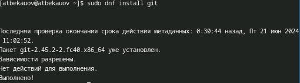

## Базовая настройка git

Далее задаю имя и email владельца репозитория, Настраиваю utf-8 в выводе сообщений git, задаю имя начальной ветки и указываю параметры autocrlf и safecrlf

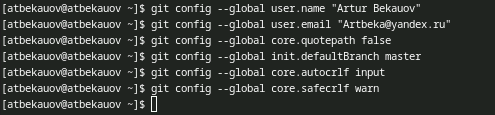

## Создание pgp ключа

Затем создаю pgp ключ, по указанным в методчке параметрам.

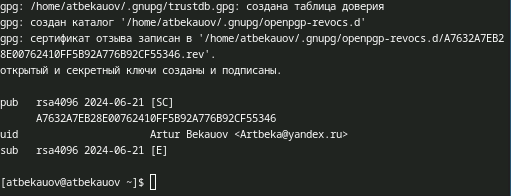

## Вывод списка ключей

После этого вывожу список ключей и копирую отпечаток приватного ключа.

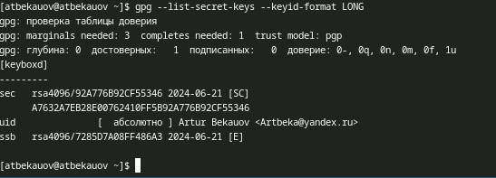

## Копирование ключа

У меня не корректно работал xclip, поэтому вывожу ключ в терминале, и копирую его вручную в буфер обмена.

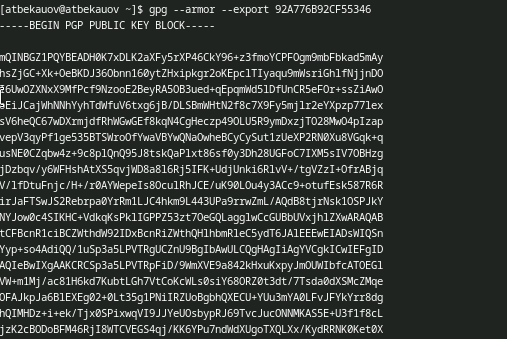

## Добавление GPG ключа в GitHub

Перейдя в GitHub в браузере, авторизуюсь и добавляю новый GPG ключ под названием Sway, куда вставляю из буфера созданный ключ.

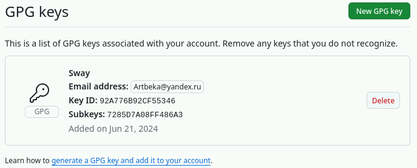

## Автоматические подписи коммитов

Далее настраиваю автоматическую подпись коммитов

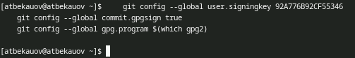

## Авторизация устройства в GH

Затем провожу авторизацию в github, выбираю авторизоваться через браузер и вхожу там в свой аккаунт github.

[figure not shown]

## Создание репозитория по шаблону

После создаю репозиторий в GH по шаблону приложенному в методичке.

[figure not shown]

## Создание каталога для репозитория

Далее создаю каталог ~/work/study/2022-2023/“Операционные системы”

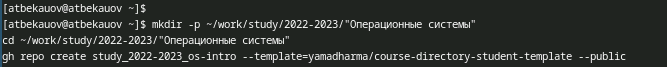

## Создание ssh ключей

Далее я создаю ssh ключи

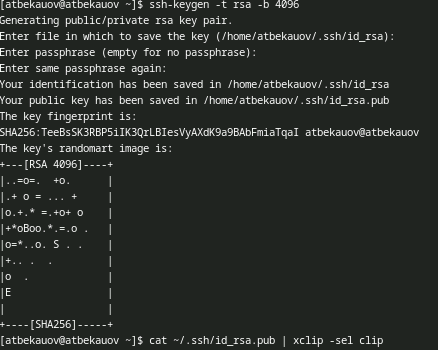

## Добавление ssh ключа

Скопировал ключ в буфер обмена и добавил на GH c названием sway.

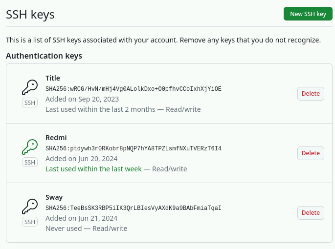

## Копирование репозитория курса

После этого клонирую созданный репозиторий в приготовленную ранее папку (локальный репозиторий называю os-intro)

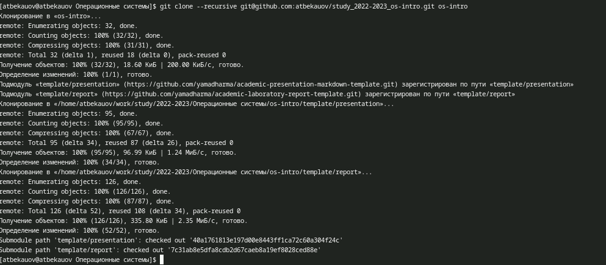

## Отправка изменений на сервер

Произвожу описанные в методичке действия с файлами реопзитория и отправляю изменения на сервер

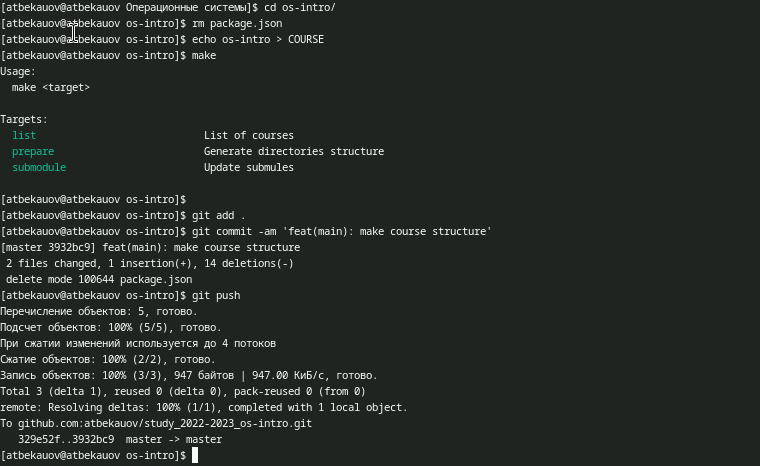

# Заключение

## Выводы

В ходе данной лаботраторной работы я изучил идеологии и применения средств контроля версий, освоил умения по работе с git.